# Harnessing the Power of Transformers for Vision

- Subhaditya Mukherjee

[figure not shown]

[figure not shown]

# Before we move on,

- All the code, slides, references are on -> https://github.com/SubhadityaMukherjee/transformer_networks
- This whole presentation is a Jupyter Notebook (Do you want to know how? Ask!)
- More resources on learning all this
- Write your questions down. FAQ/Email
  - msubhaditya@gmail.com
- Contact me on : https://www.linkedin.com/in/subhaditya-mukherjee-a36883100/
- **SCREENSHOT THIS PAGE!**

# What you get if you stay

- An understanding of what Transformers are, and why they took over the world
- Wait, wasn't it for Language?
- All the building blocks to understand!
- **Attention! Attention!**
- Finally, Vision Transformers
- Transformers vs CNNs? FIGHT!
- How can I use them? + Code demos
- Use cases - Medical Imaging
- Further questions answered. But you need to ask them of course :)
  - Lots of content! So if you want more explanations, well, stay and ask

# A Disclaimer

- Survey
  - Most of you know about RNNs + Have used them before
  - You somewhat know your way around Neural networks and implementing them
  - You have heard of Transformers
- If this is not you

[figure not shown]

- As a wise man once said

[figure not shown]

- Get the intuition now, resources incoming
- Recognize the terms

# What?

- Neural Network Architecture
- Not Convolutional (some are)
- Encoder|Decoder
- Initially for Text, now adapted for Images

# Why Bother with ViT?

- Reason : Almost 4 times more accurate than current CNNs (T&C apply)
- Stuff like : https://imagen.research.google/ , https://openai.com/blog/dall-e/
- What a time to be alive :O
- Reason 3 ... $\infty$ : We will see

# A Very Quick Little Refresher / What to learn Before ViT

[figure not shown]

# Seq2Seq Models

## Translation

[figure not shown]

## Image Captioning

[figure not shown]

- Solved using architectures such as RNNs, LSTMs etc

# So, why Transformers?

- Reminder! Intuition >> Understanding everything all at once

# RNN

[figure not shown]

- Vanishing/exploding gradient problem

## Backprop Through Time

[figure not shown]

- Stopped working when sentences were too long
- Onward!

# LSTM

- Long Short Term Memory

[figure not shown]

- Smaller chance of exploding/vanishing gradients
- Longer term dependencies!
- Gates -> Choose what to remember, and forget!
- Sadly, these too broke down when it came to longer sentences
- Followed up by many attempts to fix this
  - Bi-directional variants
  - Variants of the gates
  - Gradient Clipping
  - Convolutional RNNs
  - GRU

# GRU

- Gated Recurrent Unit
- Input, Forget gate
- Simplified LSTM -> Faster!

[figure not shown]

- But performs worse in many cases ):
- And thus we have, drumroll

[figure not shown]

# Intermission - What is the problem?

- Very long sentences
- Forgets things after a while
- Not very great at understanding context
  - Let's eat, Grandma, I am starving.
  - Let's eat Grandma, I am starving.
- What exactly is important in a sentence?
  - The **boy** **plays** with the **ball**
  - **Eating** a **mango**, she **says**, hi!
- How do we solve this?
  - What is *important*

## In Images

[figure not shown]

## Now for text

[figure not shown]

# How?

- Every word -> Embedding
- Represent in vector space
- The closer the "distance", the closer the words are
  - Eg: King, Throne ; Food, Dosa

[figure not shown]

```python
import numpy as np
vec1 = np.array([1, 1, 1, 1, 1])

vec2 = np.array([1, 1, 1, 1, 1])
vec3 = np.array([1, 1, 1, 1, 2])
# Pairwise product -> Summed up

np.dot(vec1, vec2) , np.dot(vec1, vec3)
```

```
(5, 6)
```

- Weighted sum over all the embedding vectors
- Weighted by their **normalized dot products**
- How related the words in the sequence are

[figure not shown]

```python
from numpy import array
from numpy import argmax
from sklearn.preprocessing import LabelEncoder
from sklearn.preprocessing import OneHotEncoder
from numpy import random
from numpy import dot
from scipy.special import softmax
import seaborn as sns
# define example
data = ["boy", "playing", "with", "ball"]
vecs = return_vecs(data)
words= vecs.copy()
sz = vecs[0].size
# generating the weight matrices
random.seed(42)
W_Q = random.randint(sz, size=(sz, sz))
W_K = random.randint(sz, size=(sz, sz))
W_V = random.randint(sz, size=(sz, sz))
# generating the queries, keys and values
Q = words @ W_Q
K = words @ W_K
V = words @ W_V
# scoring the query vectors against all key vectors
scores = Q @ K.transpose()
# computing the weights by a softmax operation
weights = softmax(scores / K.shape[1] ** 0.5, axis=1)

# computing the attention by a weighted sum of the value vectors
attention = weights @ V
```

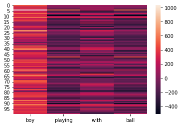

```python
import numpy as np
sns.heatmap(np.transpose(np.matrix(attention)), xticklabels=data)
```

# An Awesome tool!

- https://github.com/jessevig/bertviz

```python
head_view(attention, tokens, sentence_b_start)
```

Layer: Attention:

[interactive chart not shown]

```python
model_view(attention, tokens)  # Display model view
```

[interactive chart not shown]

# I Want Images -.-

# Converting to a sequence

[figure not shown]

# Positional Encoding

- How do we make sure the images do not get lost in learning?
  - Compared to text sequences

[figure not shown]

$$PE(pos, 2i) = sin(\frac{pos}{10000^\frac{2i}{d_{model}}})$$$$PE(pos, 2i) = cos(\frac{pos}{10000^\frac{2i}{d_{model}}})$$

# Architecture of Basic Transformer

- We have all the building blocks!

[figure not shown]

# Perks?

- Parallelization for the heads!
- Attention maps (heads up for medical use)

[figure not shown]

- Less number of lower layers to represent data vs CNN

# !Perks?

- Expensive to train
  - But does better with pretrained (that you can get, but cannot train)
- Needs a LOT of data
- Not the first thing to try IMO
- You can train huge huge models
  - But resource constraints

# When to use Vision Transformers?

- You have enough data/or it is a standard task
- CNNs just are not doing it for you
- More research + Experiments!

# How can you use it?

- Hugging Face

[figure not shown]

```python
from transformers import ViTFeatureExtractor, ViTForImageClassification
from PIL import Image
import requests

impath = "images/cat.jpg"
image = Image.open(impath)

feature_extractor = ViTFeatureExtractor.from_pretrained("google/vit-base-patch16-224")
model = ViTForImageClassification.from_pretrained("google/vit-base-patch16-224")

inputs = feature_extractor(images=image, return_tensors="pt")
outputs = model(**inputs)
logits = outputs.logits
# model predicts one of the 1000 ImageNet classes
predicted_class_idx = logits.argmax(-1).item()
print("Predicted class:", model.config.id2label[predicted_class_idx])
```

```
Predicted class: Egyptian cat
```

- From scratch
- https://github.com/SubhadityaMukherjee/transformer_networks/
- https://uvadlc-notebooks.readthedocs.io/en/latest/tutorial_notebooks/JAX/tutorial15/Vision_Transformer.html
- Further resources
  - All on the repository

[figure not shown]

- https://www.linkedin.com/in/subhaditya-mukherjee-a36883100/
- msubhaditya@gmail.com